# Diamonds Dataset Analysis

Ammar Al-Hawashem

28/09/2021

## **Part1:**

### Set-up

Let’s brong the built-in dataset to our environment: **data(diamonds)**

## **Part2:**

### Dataset’s variabls with their descriptions:

| Variable | Description |
| --- | --- |
| price | Price in US dollars ($326 – $18,823) |
| carat | Weight of the diamond (0.2 – 5.01) |
| cut | Quality of the cut (Fair, Good, Very Good, Premium, Ideal) |
| color | Diamond colour, from D (best) to J (worst) |
| clarity | A measurement of how clear the diamond is (I1 (worst), SI2, SI1, VS2, VS1, VVS2, VVS1, IF (best)) |
| x | Length in mm (0 – 10.74) |
| y | Width in mm (0 – 58.9) |
| z | Depth in mm (0 – 31.8) |
| depth | Total depth percentage = z / mean(x, y) = 2 * z / (x + y) (43–79) |
| table | Width of top of diamond relative to widest point (43–95) |

## **Part3:**

### Exploring the structure of the dataset

Firstly, install tidyverse package: **library(tidyverse)** since some of its functions will be used frequently

```r
glimpse(diamonds)
```

```
## Rows: 53,940
## Columns: 10
## $ carat   <dbl> 0.23, 0.21, 0.23, 0.29, 0.31, 0.24, 0.24, 0.26, 0.22, 0.23, 0.~
## $ cut     <ord> Ideal, Premium, Good, Premium, Good, Very Good, Very Good, Ver~
## $ color   <ord> E, E, E, I, J, J, I, H, E, H, J, J, F, J, E, E, I, J, J, J, I,~
## $ clarity <ord> SI2, SI1, VS1, VS2, SI2, VVS2, VVS1, SI1, VS2, VS1, SI1, VS1, ~
## $ depth   <dbl> 61.5, 59.8, 56.9, 62.4, 63.3, 62.8, 62.3, 61.9, 65.1, 59.4, 64~
## $ table   <dbl> 55, 61, 65, 58, 58, 57, 57, 55, 61, 61, 55, 56, 61, 54, 62, 58~
## $ price   <int> 326, 326, 327, 334, 335, 336, 336, 337, 337, 338, 339, 340, 34~
## $ x       <dbl> 3.95, 3.89, 4.05, 4.20, 4.34, 3.94, 3.95, 4.07, 3.87, 4.00, 4.~
## $ y       <dbl> 3.98, 3.84, 4.07, 4.23, 4.35, 3.96, 3.98, 4.11, 3.78, 4.05, 4.~
## $ z       <dbl> 2.43, 2.31, 2.31, 2.63, 2.75, 2.48, 2.47, 2.53, 2.49, 2.39, 2.~
```

```r
# OR  use the base function: str(diamonds)
```

## **Part4:**

### Summary of the dataset

To build a great intuition about the dataset, **let’s use:**

```r
summary(diamonds)
```

```
##      carat               cut        color        clarity          depth
##  Min.   :0.2000   Fair     : 1610   D: 6775   SI1    :13065   Min.   :43.00
##  1st Qu.:0.4000   Good     : 4906   E: 9797   VS2    :12258   1st Qu.:61.00
##  Median :0.7000   Very Good:12082   F: 9542   SI2    : 9194   Median :61.80
##  Mean   :0.7979   Premium  :13791   G:11292   VS1    : 8171   Mean   :61.75
##  3rd Qu.:1.0400   Ideal    :21551   H: 8304   VVS2   : 5066   3rd Qu.:62.50
##  Max.   :5.0100                     I: 5422   VVS1   : 3655   Max.   :79.00
##                                     J: 2808   (Other): 2531
##      table           price             x                y
##  Min.   :43.00   Min.   :  326   Min.   : 0.000   Min.   : 0.000
##  1st Qu.:56.00   1st Qu.:  950   1st Qu.: 4.710   1st Qu.: 4.720
##  Median :57.00   Median : 2401   Median : 5.700   Median : 5.710
##  Mean   :57.46   Mean   : 3933   Mean   : 5.731   Mean   : 5.735
##  3rd Qu.:59.00   3rd Qu.: 5324   3rd Qu.: 6.540   3rd Qu.: 6.540
##  Max.   :95.00   Max.   :18823   Max.   :10.740   Max.   :58.900
##
##        z
##  Min.   : 0.000
##  1st Qu.: 2.910
##  Median : 3.530
##  Mean   : 3.539
##  3rd Qu.: 4.040
##  Max.   :31.800
##
```

## **Part5:**

### Apply some calculations

*A- How many diamonds with a clarity of category “IF” are present in the data-set?*

There are many way to calculate this. Here are four different methods:

1. The nested way:

```r
nrow(diamonds[diamonds$clarity=="IF",])
```

2. By using the forward piping of tidyverse with the exact name of variable (column):

```r
diamonds %>%
    filter(clarity=="IF") %>%
    nrow() -> ifnum
    ifnum
```

3. The shortest way:

```r
sum(diamonds$clarity=="IF")
```

4. By using the forward piping of tidyverse with the index of variable (column):

```r
clarity_IF <- diamonds[4] %>%
      filter(clarity == "IF")
    count(clarity_IF)
```

All of them will give us the same result: **1790**. However, 1,2 & 3 as a vector while 4 is as tibble

*B- How many diamonds in each clarity category are present in the data-set?*

```r
table(diamonds$clarity) # a named vector
```

```
##
##    I1   SI2   SI1   VS2   VS1  VVS2  VVS1    IF
##   741  9194 13065 12258  8171  5066  3655  1790
```

*C- What fraction of the total do the clarity of category “IF” represent?*

Both of the following couple of methods give the solution as a vector

```
ifnum/nrow(diamonds) #ifnum was defined in the previous question
```

```r
nrow(diamonds[diamonds$clarity=="IF",])/nrow(diamonds)
```

```
## [1] 0.03318502
```

*D- What proportion of the whole is made up of each category of clarity?*

```r
diamonds %>%
  group_by(clarity) %>%
  summarise(proportion = length(clarity)/nrow(diamonds))
```

| clarity | proportion |
| --- | --- |
| I1 | 0.01373749 |
| SI2 | 0.17044865 |
| SI1 | 0.24221357 |
| VS2 | 0.22725250 |
| VS1 | 0.15148313 |
| VVS2 | 0.09391917 |
| VVS1 | 0.06776047 |
| IF | 0.03318502 |

```r
                         # or n() instead of length(clarity)
```

*E- What is the cheapest diamond price overall?*

1. To get just the cheapest price, use:

```r
diamonds %>%
  summarise(cheapest = min(price))             # As a tibble
```

| cheapest |
| --- |
| 326 |

```r
  #OR
  min(diamonds$price)                          # AS a vector
```

```
## [1] 326
```

2. To get the full information of the cheapest diamond/s, use:

```r
diamonds[diamonds$price==min(diamonds$price),]
```

| carat | cut | color | clarity | depth | table | price | x | y | z |
| --- | --- | --- | --- | --- | --- | --- | --- | --- | --- |
| 0.23 | Ideal | E | SI2 | 61.5 | 55 | 326 | 3.95 | 3.98 | 2.43 |
| 0.21 | Premium | E | SI1 | 59.8 | 61 | 326 | 3.89 | 3.84 | 2.31 |

*F- What is the range of diamond prices?*

```r
diamonds %>%
  summarise(range = max(diamonds$price) - min(diamonds$price))
```

| range |
| --- |
| 18497 |

*G- What is the average diamond price in each category of cut and color?*

```r
diamonds %>%
  group_by(color,cut) %>%
  summarise(average = mean(price)) # -> avgPrice_cut_color view(avgPrice_cut_color)
```

| color | cut | average |
| --- | --- | --- |
| D | Fair | 4291.061 |
| D | Good | 3405.382 |
| D | Very Good | 3470.467 |
| D | Premium | 3631.293 |
| D | Ideal | 2629.095 |
| E | Fair | 3682.312 |
| E | Good | 3423.644 |
| E | Very Good | 3214.652 |
| E | Premium | 3538.914 |
| E | Ideal | 2597.550 |

[output cut: 25 more lines]

*H- Create a 2-dimensional vector that counts the number of diamonds in each category of cut and color?*

```r
table(diamonds$cut, diamonds$color) # kind of a matrix
```

```
##
##                D    E    F    G    H    I    J
##   Fair       163  224  312  314  303  175  119
##   Good       662  933  909  871  702  522  307
##   Very Good 1513 2400 2164 2299 1824 1204  678
##   Premium   1603 2337 2331 2924 2360 1428  808
##   Ideal     2834 3903 3826 4884 3115 2093  896
```

## **Part6:**

### Construct some plots

1. Univariate plot of the cuts

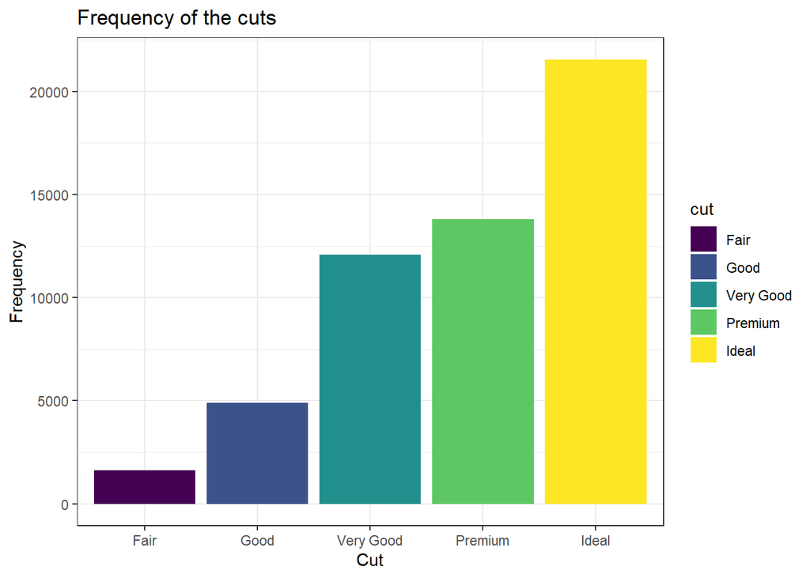

```r
#
ggplot(diamonds, aes(x= cut, fill= cut)) +
  geom_bar()+
  labs(x = "Cut",
       y = "Frequency",
       title = "Frequency of the cuts")+
  theme_bw()
```

2. Price described by carat (in one plot)

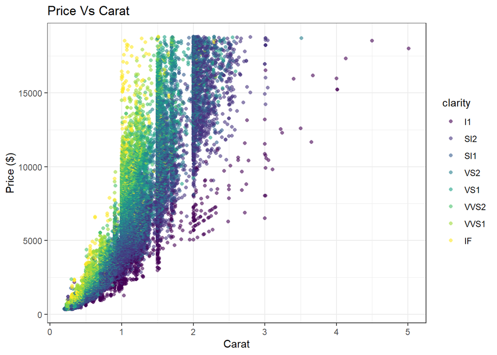

```r
ggplot(diamonds, aes(x=carat, y=price, color=clarity))+
  geom_point(alpha = 0.6,
             shape = 16)+
  labs(x = "Carat",
       y = "Price ($)",
       title = "Price Vs Carat")+
  theme_bw()
```

3. Price described by carat (plot for each clarity)

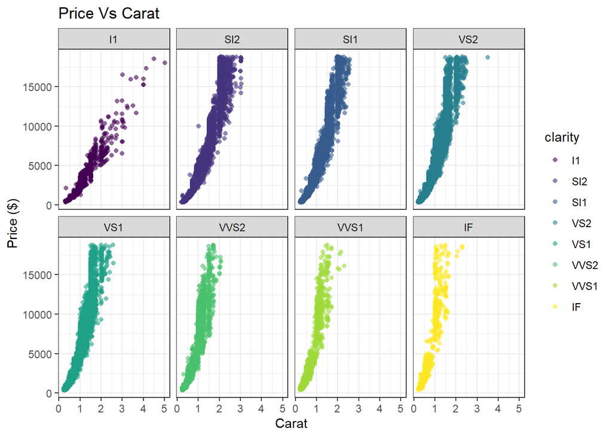

```r
ggplot(diamonds, aes(x=carat, y=price, color=clarity))+
  geom_point(alpha = 0.6,
             shape = 16)+
 facet_wrap(~ clarity, ncol = 4)+
  labs(x = "Carat",
       y = "Price ($)",
       title = "Price Vs Carat")+
  theme_bw()
```